# Inferring Immune Interactions in Breast Cancer

Orian Stapleton

2023-02-15

## Overview

SpaceMarkers leverages latent feature analysis of the spatial components of transcriptomic data to identify biologically relevant molecular interactions between cell groups.This tutorial will use the latent features from CoGAPS to look at pattern interactions in a Visium 10x breast ductal carcinoma spatial transcriptomics dataset.

## Installation

```r
#install.packages("remotes")
#remotes::install_github("FertigLab/SpaceMarkers", dependencies = TRUE, build_vignettes = TRUE)
```

## Importing Libraries

```r
library(SpaceMarkers)
```

## Obtaining and Formatting the Data

The data that will be used to demonstrate SpaceMarkers’ capabilities is a human breast cancer spatial transcriptomics dataset that comes from Visium. The CoGAPS patterns as seen in the manuscript [Atul Deshpande, Melanie Loth, et al.](https://doi.org/10.1016/j.cels.2023.03.004) will also be taken from GitHub.

```r
main_10xlink <- "https://cf.10xgenomics.com/samples/spatial-exp/1.3.0"
counts_folder <- "Visium_Human_Breast_Cancer"
counts_file <- "Visium_Human_Breast_Cancer_filtered_feature_bc_matrix.h5"
counts_url<-paste(c(main_10xlink,counts_folder,counts_file), collapse = "/")
sp_folder <- "Visium_FFPE_Human_Breast_Cancer"
sp_file <- "Visium_FFPE_Human_Breast_Cancer_spatial.tar.gz"
sp_url<-paste(c(main_10xlink,sp_folder,sp_file),collapse = "/")
cg_main <- "https://github.com/atuldeshpande/SpaceMarkers-paper/blob/main"
cg_folder <- "CoGAPS_Analysis/BreastCancer"
cg_file <- "182967_1168993F_2_CogapsResult_5.rds?raw=true"
cogaps_url <- paste(c(cg_main,cg_folder,cg_file), collapse = "/")
```

## Removing Directories

The functions require that some files and directories with the same name be unique. Therefore any downloads from a previous run will be removed.

```r
unlink(sp_file)
files <- list.files(".")[grepl(counts_file,list.files("."))]
unlink(files)
unlink("CogapsResult_5.rds")
unlink("spatial", recursive = TRUE)
```

### Extracting Counts Matrix

```r
system2("wget",c("-q",counts_url))
counts_matrix <- load10XExpr(visiumDir = ".", h5filename = counts_file)
good_gene_threshold <- 3
goodGenes <- rownames(counts_matrix)[apply(counts_matrix,1,function(x) sum(x>0)>=good_gene_threshold)]
counts_matrix <- counts_matrix[goodGenes,]
```

### Obtaining CoGAPS Patterns

```r
system2("wget",c("-q",cogaps_url,"-O","CogapsResult_5.rds"))
cogaps_result <- readRDS("CogapsResult_5.rds")
features <- intersect(rownames(counts_matrix),rownames(slot(cogaps_result,"featureLoadings")))
barcodes <- intersect(colnames(counts_matrix),rownames(slot(cogaps_result,"sampleFactors")))
counts_matrix <- counts_matrix[features,barcodes]
cogaps_matrix <- slot(cogaps_result,"featureLoadings")[features,] %*% t(slot(cogaps_result,"sampleFactors")[barcodes,])
```

### Obtaining Spatial Coordinates

The spatial coordinates will also be pulled from Visium for this dataset. These are combined with the latent features to demonstrate how cells for each pattern interact in 2D space.

```r
download.file(sp_url, basename(sp_url))
untar(basename(sp_url))
spCoords <- load10XCoords(visiumDir = ".")
rownames(spCoords) <- spCoords$barcode
spCoords <- spCoords[barcodes,]
spPatterns <- cbind(spCoords,slot(cogaps_result,"sampleFactors")[barcodes,])
head(spPatterns)
```

```
##                               barcode         y        x    Pattern_1
## AAACAACGAATAGTTC-1 AAACAACGAATAGTTC-1  79.44776 163.2886 0.4676255882
## AAACAAGTATCTCCCA-1 AAACAAGTATCTCCCA-1 355.49321 435.6841 0.2690758109
## AAACAATCTACTAGCA-1 AAACAATCTACTAGCA-1  96.05857 248.8780 0.1105933860
## AAACACCAATAACTGC-1 AAACACCAATAACTGC-1 404.91037 172.5120 0.0002508377
## AAACAGAGCGACTCCT-1 AAACAGAGCGACTCCT-1 156.88474 410.5056 0.2849308848
## AAACAGCTTTCAGAAG-1 AAACAGCTTTCAGAAG-1 316.63265 140.8859 0.1583736390
##                       Pattern_2    Pattern_3    Pattern_4    Pattern_5
## AAACAACGAATAGTTC-1 1.049391e-01 2.576064e-01 0.6848062277 4.747092e-02
## AAACAAGTATCTCCCA-1 4.394425e-01 2.056469e-01 0.2921337187 1.167576e-02
## AAACAATCTACTAGCA-1 1.148523e-02 2.309153e-01 0.4111314714 9.508318e-02
## AAACACCAATAACTGC-1 1.685795e-01 1.223603e-01 0.0001562788 8.041928e-01
## AAACAGAGCGACTCCT-1 1.102506e-01 9.053156e-08 0.2429406196 3.430807e-08
## AAACAGCTTTCAGAAG-1 9.741083e-06 1.723470e-01 0.3059957027 7.167605e-01
```

## Executing SpaceMarkers

### SpaceMarker Modes

SpaceMarkers can operate in ‘residual’ mode or ‘DE’ (Differential Expression mode). In an ideal world the overlapping patterns identified by SpaceMarkers would be a homogeneous population of cells and the relationship between them would be linear. However, due to confounding effects of variations in cell density and common cell types in any given region, this is not always true.

To account for these confounding effects, the ‘residual’ mode compares the feature interactions between the expression matrix and the reconstructed latent space matrix. The features with the highest residual error are reported. The genes are then classified according to regions of overlapping vs exclusive influence. The default mode is ‘residual’ mode.

Suppose the feature (gene) information is not readily available and only the sample (cells) latent feature patterns with P-values are available? This is the advantage of ‘DE’ mode. Where residual mode assesses the non-linear effects that may arise from confounding variables, ‘DE’ mode assesses simple linear interactions between patterns directly from expression. DE mode also compares genes from regions of overlapping vs exclusive influence but does not consider residuals from the expression matrix as there is no matrix reconstruction with the latent feature matrix.

To demonstrate SpaceMarkers we will be looking at Pattern_1 from CoGAPS. Pattern_1 was identified as mainly an immune cell driven pattern. Pattern_1 is the default setting if no Pattern_n preference is given by the user.

### Residual Mode

SpaceMarkers identifies regions of influence using a gaussian kernel outlier based model. The reference pattern (Pattern_1 in this case) is used as the prior for this model. SpaceMarkers then identifies where the regions of influence are interacting from each of the other patterns as well as where they are mutually exclusive.

getSpatialParameters: This function identifies the optimal width of the gaussian distribution (sigmaOpt) as well as the outlier threshold around the set of spots (thresOpt) for each pattern.These parameters minimize the spatial autocorrelation residuals of the spots in the regions of influence. This function can take a while so the file would be read in from the data folder for this tutorial.

getSpatialParameters took approximately 12 minutes on a MacBook Pro Quad-Intel Core i5 processor with 16 GB of memory. Therefore the saved output would be used

```r
SpaceMarkersMode = "residual"
SpaceMarkersRefPattern = "Pattern_1"
```

```r
optParams <- getSpatialParameters(spPatterns)
```

```r
data("optParams_breast_cancer")
optParams <- optParams_breast_cancer
head(optParams)
```

```
##           Pattern_1 Pattern_2 Pattern_3 Pattern_4 Pattern_5
## sigmaOpt        7.0       7.8       6.0       7.2       6.4
## threshOpt       2.1       1.3       2.6       1.5       1.2
```

getInteractingGenes: This function identifies the regions of influence and interaction as well as the genes associated with these regions. A non-parametric Kruskal-Wallis test is used to identify statistically significant genes in any one region of influence without discerning which region is more significant. A post hoc Dunn’s Test is used for analysis of genes between regions and can distinguish which of two regions is more significant. If ‘residual’ mode is selected the user must provide a reconstructed matrix from the latent feature matrix. This is passed to the ‘reconstruction’ argument and can be left as NULL for ‘DE’ mode. The ‘data’ parameter is the original expression matrix. The ‘spatialPatterns’ argument takes a matrix with the spatial coordinates of each cell as well as the patterns. The spatial coordinate columns must have the labels x and y.

getInteractingGenes also takes several minutes on a MacBook Pro with an Intel Core i5 processor and 16 GB of memory, so for both residual and DE mode, the saved data from a previous run will be used.

```r
SpaceMarkers <- getInteractingGenes(data = counts_matrix, reconstruction = cogaps_matrix, optParams = optParams,spatialPatterns = spPatterns, refPattern = SpaceMarkersRefPattern, mode = SpaceMarkersMode, analysis = "overlap")
```

NB: When running getInteractingGenes some warnings may be generated. The warnings are due to the nature of the ‘sparse’ data being used. Comparing two cells from the two patterns with identical information is redundant as SpaceMarkers is identifying statistically different expression for interactions exclusive to either of the two patterns and a region that is due to interaction between the given two patterns. Also, if there are too many zeros in the genes (rows) of those regions, the columns are dropped as there is nothing to compare in the Kruskal Wallis test.

```r
data("SpaceMarkers_Residualmode_overlap")
SpaceMarkers <- SpaceMarkers_Residualmode_overlap
```

```r
print(head(SpaceMarkers$interacting_genes[[1]]))
```

```
##                  Gene Pattern_1 x Pattern_2 KW.obs.tot KW.obs.groups KW.df
## VEPH1           VEPH1                vsBoth       2060             3     2
## IGLC3           IGLC3                vsBoth       2060             3     2
## AL355075.4 AL355075.4                vsBoth       2060             3     2
## POTEC           POTEC                vsBoth       2060             3     2
## HIST1H2BK   HIST1H2BK                vsBoth       2060             3     2
## IGHG1           IGHG1                vsBoth       2060             3     2
##            KW.statistic    KW.pvalue     KW.p.adj Dunn.zP1_Int Dunn.zP2_Int
## VEPH1          88.63261 5.671178e-20 1.789790e-19    -6.484494    -9.414016
## IGLC3         106.95965 5.943027e-24 2.075487e-23    -5.672813   -10.157492
## AL355075.4     75.88170 3.330416e-17 9.651014e-17    -6.142987    -8.710288
## POTEC          71.56722 2.879885e-16 8.075565e-16    -6.048958    -8.456695
## HIST1H2BK      64.18185 1.156350e-14 3.044447e-14    -6.402169    -7.914038
## IGHG1          85.85028 2.279542e-19 7.066548e-19    -5.392916    -9.163438
##            Dunn.zP2_P1 Dunn.pval_1_Int Dunn.pval_2_Int Dunn.pval_2_1
## VEPH1        -3.072096    8.902991e-11    4.775338e-21  2.125612e-03
## IGLC3        -5.063395    1.404719e-08    3.068687e-24  4.118562e-07
## AL355075.4   -2.653248    8.098402e-10    3.031025e-18  7.972131e-03
## POTEC        -2.463958    1.457858e-09    2.750614e-17  1.374121e-02
## HIST1H2BK    -1.326536    1.531852e-10    2.491728e-15  1.846623e-01
## IGHG1        -4.204253    6.932348e-08    5.026975e-20  2.619459e-05
##            Dunn.pval_1_Int.adj Dunn.pval_2_Int.adj Dunn.pval_2_1.adj
## VEPH1             5.860774e-10        4.797515e-20      7.110180e-03
## IGLC3             8.144239e-08        3.345231e-23      2.144958e-06
## AL355075.4        5.057933e-09        2.792981e-17      2.401584e-02
## POTEC             8.970650e-09        2.442269e-16      3.954288e-02
## HIST1H2BK         9.963317e-10        2.047930e-14      4.396893e-01
## IGHG1             3.836283e-07        4.912064e-19      1.143205e-04
##            SpaceMarkersMetric
## VEPH1                61.04513
## IGLC3                57.62155
## AL355075.4           53.50719
## POTEC                51.15419
## HIST1H2BK            50.66701
## IGHG1                49.41765
```

```r
print(head(SpaceMarkers$hotspotRegions))
```

```
##      Pattern_1   Pattern_2   Pattern_3 Pattern_4   Pattern_5
## [1,] "Pattern_1" NA          NA        "Pattern_4" NA
## [2,] NA          "Pattern_2" NA        "Pattern_4" NA
## [3,] NA          NA          NA        "Pattern_4" NA
## [4,] NA          NA          NA        NA          "Pattern_5"
## [5,] "Pattern_1" "Pattern_2" NA        NA          NA
## [6,] NA          NA          NA        NA          "Pattern_5"
```

The output is a list of data frames with information about the interacting genes of the refPattern and each pattern from the CoGAPS matrix (interacting_genes object). There is also a data frame with all of the regions of influence for any two of patterns (the hotspotRegions object).

For the ‘interacting_genes’ data frames, the first column is the list of genes and the second column says whether the expression of genes are statistically significant when compared to the refPattern only, the interacting pattern only, or both. The remaining columns are statistics for the Kruskal-Wallis test and the post hoc Dunn’s test. The SpaceMarkersMetric column is a product of the Dunn’s statistics and is used to rank the genes.

### DE Mode

As described previously ‘DE’ mode only requires the counts matrix and spatial patterns and not the reconstructed CoGAPS matrix. It identifies simpler molecular interactions between regions.

```r
SpaceMarkersMode = "DE"
SpaceMarkers_DE <- getInteractingGenes(data = counts_matrix, reconstruction = NULL, optParams = optParams,spatialPatterns = spPatterns, refPattern = SpaceMarkersRefPattern, mode = SpaceMarkersMode, analysis = "overlap")
```

```r
data("SpaceMarkers_DEmode_overlap")
SpaceMarkers_DE <- SpaceMarkers_DEmode_overlap
```

### Differences between Residual Mode and DE Mode

To highlight the differences between residual mode and DE mode, the interaction between Pattern_1 (immune cell) and Pattern_5 (invasive carcinoma lesion) will be assessed. One of the first things to notice is the difference in the number of genes identified between the two modes.

```r
residual_p1_p2<-SpaceMarkers$interacting_genes[[4]]
DE_p1_p2<-SpaceMarkers_DE$interacting_genes[[4]]
```

[output not shown]

DE mode identified more genes because it does not consider noise that may be associated with common cell types in the interacting regions while residual mode considers these and other confounding variables by taking the residuals between the counts and reconstructed latent feature matrix. The next analysis will show where the top genes rank in each mode’s list if they are identified at all. A function was created that will take the top 20 genes of a reference list of genes and compares it to the entire list of a second list of genes. The return object is a data frame of the gene, the name of each list and the ranking of each gene as compared to the reference list. If there is no gene identified in the second list compared to the reference it is classified as NA.

```r
compare_genes <- function(ref_list, list2,ref_name = "mode1",list2_name = "mode2", sub_slice = NULL){
    if (is.null(sub_slice)) {
        ref_rank <- seq(1,length(ref_list),1)
    } else {
        ref_rank <- which(ref_list %in% ref_list[sub_slice])
        ref_list <- ref_list[ref_rank]
    }

    list2_ref_rank <- which(list2 %in% ref_list)
    list2_ref_genes <- list2[which(list2 %in% ref_list)]
    ref_genes_only <- ref_list[ !ref_list  %in% list2_ref_genes ]
    mode1 <- data.frame("Gene" = ref_list,"Rank" = ref_rank,"mode"= ref_name)
    mode2 <- data.frame("Gene" = c(list2_ref_genes, ref_genes_only),"Rank" = c(list2_ref_rank,rep(NA,length(ref_genes_only))),"mode"= list2_name)
    mode1_mode2 <- merge(mode1, mode2, by = "Gene", all = TRUE)
    mode1_mode2 <- mode1_mode2[order(mode1_mode2$Rank.x),]
    mode1_mode2 <- subset(mode1_mode2,select = c("Gene","Rank.x","Rank.y"))
    colnames(mode1_mode2) <- c("Gene",paste0(ref_name,"_Rank"),paste0(list2_name,"_Rank"))
    return(mode1_mode2)
}
```

```r
res_to_DE <- compare_genes( head(residual_p1_p2$Gene, n = 20) ,DE_p1_p2$Gene,ref_name = "residual",list2_name = "DE" )
DE_to_res <- compare_genes(head(DE_p1_p2$Gene, n = 20),residual_p1_p2$Gene,ref_name = "DE",list2_name = "residual" )
```

#### Comparing residual mode to DE mode

```r
res_to_DE
```

```
##        Gene residual_Rank DE_Rank
## 2     APOC1             1       1
## 15     IGHE             2      10
## 14    IFI30             3       6
## 6       CLU             4      13
## 10     CST1             5       4
## 5      CAPG             6      16
## 19     TGM2             7      14
## 4      C1QC             8      48
## 3      C1QB             9      NA
## 18    PHGR1            10      51
## 11      FAH            11      47
## 16   LAPTM5            12      40
## 20    TREM2            13      12
## 12    GCHFR            14      11
## 8    COL4A1            15      26
## 13 HLA-DRB1            16      NA
## 7   COL18A1            17      29
## 9      COMP            18      37
## 1    AKR1A1            19      35
## 17   NDUFB2            20      18
```

Here we identify the top 20 genes in ‘residual’ mode and their corresponding ranking in DE mode. APOC1,IGHE,IFI30,CLU,CST1,CAPG,TGM2,TREM2 and GCHFR are ranked high in both ‘DE’ and ‘residual’ mode. While 2 genes that are ranked high in ‘residual’ mode are not identified at all in ‘DE’ mode

#### Comparing DE mode to residual mode

```r
DE_to_res
```

```
##      Gene DE_Rank residual_Rank
## 2   APOC1       1             1
## 10    FTL       2            NA
## 8    CTSD       3            NA
## 6    CST1       4             5
## 3    APOE       5            21
## 13  IFI30       6             3
## 16   PSAP       7            64
## 17    SDS       8           203
## 1    ACTB       9            NA
## 14   IGHE      10             2
## 11  GCHFR      11            14
## 19  TREM2      12            13
## 5     CLU      13             4
## 18   TGM2      14             7
## 12  HLA-A      15            NA
## 4    CAPG      16             6
## 7    CTSB      17           274
## 15 NDUFB2      18            20
## 9    FTH1      19            NA
## 20    UBC      20            NA
```

There were 6 genes that were interacting in ‘DE’ mode but not ‘residual’ mode. Recall that DE mode looks at the information encoded in the latent feature space and does not filter out genes based on any confounders between the counts matrix and latent feature matrix as is done in ‘residual’ mode.

There is some agreement with interacting genes between the two methods but there are also quite a few differences. Therefore, the selected mode can significantly impact the downstream results and should be taken into consideration based on the specific biological question being answered and the data available.

## Types of Analyses

One new feature of the SpaceMarkers package is the type of analysis that can be carried out, whether ‘overlap’ or ‘enrichment’ mode. The major difference between the two is that enrichment mode includes genes even if they did not pass the multi-test correction for the KW test. These additional genes were included to enable a more statistically powerful pathway enrichment analysis and understand to a better extent the impact of genes involved each pathway.

### Residual Mode and DE Mode - Enrichment

```r
SpaceMarkersMode = "residual"
SpaceMarkers_DE <- getInteractingGenes(data = counts_matrix, reconstruction = NULL, optParams = optParams,spatialPatterns = spPatterns, refPattern = SpaceMarkersRefPattern, mode = SpaceMarkersMode, analysis = "enrichment")
```

```r
data("SpaceMarkers_Residualmode_enrichment")
SpaceMarkers_enrich <- SpaceMarkers_Residualmode_enrichment
```

```r
SpaceMarkersMode = "DE"
SpaceMarkers_DE <- getInteractingGenes(data = counts_matrix, reconstruction = NULL, optParams = optParams,spatialPatterns = spPatterns, refPattern = SpaceMarkersRefPattern, mode = SpaceMarkersMode, analysis = "enrichment")
```

```r
data("SpaceMarkers_DEmode_enrichment")
SpaceMarkers_DE_enrich <- SpaceMarkers_DEmode_enrichment
```

#### Comparing Enrichment Analyses

```r
residual_p1_p2_enrich <- SpaceMarkers_enrich$interacting_genes[[4]]
DE_p1_p2_enrich <- SpaceMarkers_DE_enrich$interacting_genes[[4]]
```

```r
enrich_res_to_de <- compare_genes( head(residual_p1_p2_enrich$Gene, n = 20) ,DE_p1_p2_enrich$Gene,ref_name = "residual_Enrich",list2_name = "DE_Enrich" )
enrich_res_to_de
```

```
##          Gene residual_Enrich_Rank DE_Enrich_Rank
## 4       APOC1                    1              1
## 13       IGHE                    2             10
## 12      IFI30                    3              6
## 9        CST1                    4              4
## 8         CLU                    5             13
## 19      TIMP4                    6          13049
## 3  AC012236.1                    7           6961
## 2  AC006064.2                    8          14289
## 16      PGAM2                    9          19179
## 6   C20orf197                   10           6545
## 11       GPD1                   11          10895
## 18    SLC19A3                   12          13048
## 20     ZNF773                   13          20811
## 17       SAA2                   14          20595
## 5    C1orf127                   15          12281
## 15     OR2I1P                   16          16819
## 1  AC002451.1                   17          19570
## 14      L1TD1                   18           9690
## 10     DUSP18                   19          19124
## 7        CAPG                   20             17
```

As seen before there are significant differences between DE and residual mode with how the genes are ordered. However, both methods are ranking the few genes highly possibly due to greater biological importance.

```r
overlap_enrich_de <- compare_genes( head(DE_p1_p2$Gene, n = 20) ,DE_p1_p2_enrich$Gene,ref_name = "DE_Enrich",list2_name = "DE_Overlap" )
overlap_enrich_de
```

```
##      Gene DE_Enrich_Rank DE_Overlap_Rank
## 2   APOC1              1               1
## 10    FTL              2               2
## 8    CTSD              3               3
## 6    CST1              4               4
## 3    APOE              5               5
## 13  IFI30              6               6
## 16   PSAP              7               7
## 17    SDS              8               8
## 1    ACTB              9               9
## 14   IGHE             10              10
## 11  GCHFR             11              11
## 19  TREM2             12              12
## 5     CLU             13              13
## 18   TGM2             14              14
## 12  HLA-A             15              15
## 4    CAPG             16              17
## 7    CTSB             17              19
## 15 NDUFB2             18              16
## 9    FTH1             19              18
## 20    UBC             20              20
```

The enrichment analysis and overlap analysis are in great agreement, with only a few small changes.

```r
overlap_enrich_de_later <- compare_genes( DE_p1_p2$Gene ,DE_p1_p2_enrich$Gene,ref_name = "DE_Enrich",list2_name = "DE_Overlap", sub_slice = 30:50)
overlap_enrich_de_later
```

```
##      Gene DE_Enrich_Rank DE_Overlap_Rank
## 20  SULF1             30              27
## 16   PFN1             31              32
## 19   RPS2             32              33
## 4    CD74             33              34
## 5    CD81             34              35
## 1  AKR1A1             35              36
## 12   MMP1             36              31
## 7    COMP             37              37
## 6    CFL1             38              38
## 13  NUPR1             39              41
## 10 LAPTM5             40              39
## 18  PRDX1             41              42
## 14   OAZ1             42              46
## 21   TUBB             43              44
## 9   HTRA3             44              43
## 17  POSTN             45              45
## 15   PAXX             46              51
## 8     FAH             47              49
## 3    C1QC             48              47
## 11 LGALS3             49              50
## 2  ARPC1B             50              48
```

Further down the gene list, the ranking begins to shuffle alot more.Since the SpaceMarkersMetric only takes into account the Dunn’s test, the genes, genes that may not have passed the correction for the KW test inititally are now taken into account with great differences between any two patterns.

## Enrichment Analysis

```r
library(org.Hs.eg.db)
library(clusterProfiler)
library(enrichplot)
library(ggplot2)
```

In this particular analysis we will use the ‘enrichment’ genes for residual mode as a background and the ‘overlap’ genes to search for enrichment

```r
matx2 <- AnnotationDbi::select(org.Hs.eg.db, keys=residual_p1_p2_enrich[,"Gene"], columns=c("ENTREZID","GENENAME"), keytype="ALIAS")
etz_df <- merge(x=matx2[-which(duplicated(matx2$ALIAS)),],y=residual_p1_p2_enrich, by.x="ALIAS", by.y="Gene",all.x=TRUE)
etz_df <- etz_df[!is.na(etz_df$ENTREZID),]
etz_df <- etz_df[!duplicated(etz_df$ENTREZID),]
original_gene_list <- etz_df$SpaceMarkersMetric
# name the vector
names(original_gene_list) <- etz_df$ENTREZID

# omit any NA values
universe <- na.omit(original_gene_list)
universe <- universe[!duplicated(universe)]
# sort the list in decreasing order (required for clusterProfiler)
universe = sort(universe, decreasing = TRUE)

#Regular Gene list
target_genes <- AnnotationDbi::select(org.Hs.eg.db, keys=residual_p1_p2[,"Gene"], columns=c("ENTREZID","GENENAME"), keytype="ALIAS")
gene_list <- target_genes$ENTREZID[ target_genes$ENTREZID %in% names(universe)]
```

```r
gse <- enrichKEGG(gene =unique(gene_list), universe = names(universe))
```

```
## Reading KEGG annotation online: "https://rest.kegg.jp/link/hsa/pathway"...
```

```
## Reading KEGG annotation online: "https://rest.kegg.jp/list/pathway/hsa"...
```

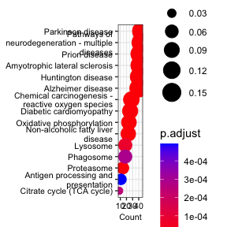

```r
dotplot(gse, showCategory=15, x = 'Count', font.size = 8)
```

## Comparing Patterns Spatially

The differences between the gene interactions of Pattern_1 (immune cell) and Pattern_5 (invasive carcinoma lesion) can be visualized in various ways to view both the magnitude and location of expression in space. In this analysis the top 2-3 genes in residual mode from Pattern_5 only vs Pattern_1, Pattern_1 only vs Pattern_5 and the interacting region vs both Pattern_1 and Pattern_5 will be compared.

The following libraries are required to make the plots:

```r
library(Matrix)
library(rjson)
library(cowplot)
library(RColorBrewer)
library(grid)
library(readbitmap)
library(dplyr)
library(data.table)
library(viridis)
library(hrbrthemes)
```

This first function below can visualize the locations of these patterns on a spatial grid. The code has been adopted from [10xgenomics](https://support.10xgenomics.com/spatial-gene-expression/software/pipelines/latest/rkit)

```r
geom_spatial <-  function(mapping = NULL,
    data = NULL,
    stat = "identity",
    position = "identity",
    na.rm = FALSE,
    show.legend = NA,
    inherit.aes = FALSE,
    ...) {

    GeomCustom <- ggproto(
        "GeomCustom",
        Geom,
        setup_data = function(self, data, params) {
            data <- ggproto_parent(Geom, self)$setup_data(data, params)
            data
        },

        draw_group = function(data, panel_scales, coord) {
            vp <- grid::viewport(x=data$x, y=data$y)
            g <- grid::editGrob(data$grob[[1]], vp=vp)
            ggplot2:::ggname("geom_spatial", g)
        },

        required_aes = c("grob","x","y")

    )

    layer(geom = GeomCustom,mapping = mapping,data = data,stat = stat,position = position,show.legend = show.legend,inherit.aes = inherit.aes,params = list(na.rm = na.rm, ...)
    )
}
```

Some spatial information for the breast cancer dataset is required.

```r
sample_names <- c("BreastCancer")
image_paths <- c("spatial/tissue_lowres_image.png")
scalefactor_paths <- c("spatial/scalefactors_json.json")
tissue_paths <- c("spatial/tissue_positions_list.csv")

images_cl <- list()

for (i in 1:length(sample_names)) {
    images_cl[[i]] <- read.bitmap(image_paths[i])
}

height <- list()

for (i in 1:length(sample_names)) {
    height[[i]] <-  data.frame(height = nrow(images_cl[[i]]))
}

height <- bind_rows(height)

width <- list()

for (i in 1:length(sample_names)) {
    width[[i]] <- data.frame(width = ncol(images_cl[[i]]))
}

width <- bind_rows(width)

grobs <- list()
for (i in 1:length(sample_names)) {
    grobs[[i]] <- rasterGrob(images_cl[[i]], width=unit(1,"npc"), height=unit(1,"npc"))
}

images_tibble <- tibble(sample=factor(sample_names), grob=grobs)
images_tibble$height <- height$height
images_tibble$width <- width$width


scales <- list()

for (i in 1:length(sample_names)) {
    scales[[i]] <- rjson::fromJSON(file = scalefactor_paths[i])
}
```

It is also helpful to adjust spot position by scale factor and format some of the tissue information.

```r
bcs <- list()
for (i in 1:length(sample_names)) {
    bcs[[i]] <- read.csv(tissue_paths[i],col.names=c("barcode","tissue","row","col","imagerow","imagecol"), header = FALSE)
    bcs[[i]]$imagerow <- bcs[[i]]$imagerow * scales[[i]]$tissue_lowres_scalef# scale tissue coordinates for lowres image
    bcs[[i]]$imagecol <- bcs[[i]]$imagecol * scales[[i]]$tissue_lowres_scalef
    bcs[[i]]$tissue <- as.factor(bcs[[i]]$tissue)
    bcs[[i]]$height <- height$height[i]
    bcs[[i]]$width <- width$width[i]
}
names(bcs) <- sample_names
```

Adding umi per spot, total genes per spot and merging the data

```r
matrix <- list()
for (i in 1:length(sample_names)) {
    matrix[[i]] <- as.data.frame(t(as.matrix(counts_matrix)))
}
umi_sum <- list()
for (i in 1:length(sample_names)) {
    umi_sum[[i]] <- data.frame(barcode =  row.names(matrix[[i]]), sum_umi = Matrix::rowSums(matrix[[i]]))

}
names(umi_sum) <- sample_names

umi_sum <- bind_rows(umi_sum, .id = "sample")
gene_sum <- list()

for (i in 1:length(sample_names)) {
    gene_sum[[i]] <- data.frame(barcode =  row.names(matrix[[i]]),sum_gene=Matrix::rowSums(matrix[[i]] != 0))

}
names(gene_sum) <- sample_names
gene_sum <- bind_rows(gene_sum, .id = "sample")
bcs_merge <- bind_rows(bcs, .id = "sample")
bcs_merge <- merge(bcs_merge,umi_sum, by = c("barcode", "sample"))
bcs_merge <- merge(bcs_merge,gene_sum, by = c("barcode", "sample"))
```

Specifying a continuous scale and colors before plotting

```r
xlim(0,max(bcs_merge%>%dplyr::filter(sample ==sample_names[i])%>%select(width)))
```

```
## <ScaleContinuousPosition>
##  Range:
##  Limits:    0 --  600
```

```r
#myPalette <- colorRampPalette(rev(brewer.pal(11, "Spectral")))
myPalette <- function(numLevels) {return(colorRampPalette(c("blue","yellow"))(numLevels))}
```

Extracting top 3 genes …

```r
gene_list <- c()
interactions <- unique(residual_p1_p2$`Pattern_1 x Pattern_5`)
n_genes <- 3
for (g in 1:length(interactions)){
    df <- residual_p1_p2 %>% dplyr::filter(residual_p1_p2$`Pattern_1 x Pattern_5` == interactions[g] & abs(residual_p1_p2$Dunn.zP2_P1) > 1 )
    print(paste0("Top ",n_genes," genes for ",interactions[g]))
    print(df$Gene[1:n_genes])
    gene_list <- c(gene_list,df$Gene[1:n_genes])
}
```

```
## [1] "Top 3 genes for vsBoth"
## [1] "APOC1" "IGHE"  "IFI30"
## [1] "Top 3 genes for vsPattern_5"
## [1] "ING1" "HADH" "AAMP"
## [1] "Top 3 genes for vsPattern_1"
## [1] "RCN1"    "TMEM147" "ACTN1"
```

Visualize expression spatially

```r
plots <- list()
# default size = 1.75, stroke = 0.5
for (g in gene_list){
    for (i in 1:length(sample_names)) {
        plots[[length(plots)+1]] <- bcs_merge %>%dplyr::filter(sample ==sample_names[i]) %>% bind_cols(as.data.table(matrix[i])[,g, with=FALSE]) %>% ggplot(aes_string(x='imagecol', y='imagerow', fill=g)) +geom_spatial(data=images_tibble[i,], aes(grob=grob), x=0.5, y=0.5)+ geom_point(shape = 21, colour = "black", size = 1.1, stroke = 0.2)+coord_cartesian(expand=FALSE)+scale_fill_gradientn(colours = myPalette(100))+xlim(0,max(bcs_merge %>%dplyr::filter(sample ==sample_names[i]) %>% select(width)))+ylim(max(bcs_merge %>%dplyr::filter(sample ==sample_names[i]) %>% select(height)),0)+xlab("") +ylab("") + ggtitle(sample_names[i]) + theme_set(theme_bw(base_size = 10)) + theme(panel.grid.major= element_blank(),panel.grid.minor = element_blank(), panel.background = element_blank(),axis.line = element_line(colour = "black"), axis.text = element_blank(),axis.ticks = element_blank())
    }
}
```

This next block of code can visualize the genes for each pattern on boxplots

```r
region <- SpaceMarkers$hotspotRegions[,1]
region <- ifelse(!is.na(region) & !is.na(SpaceMarkers$hotspotRegions[,5]),"Interacting",ifelse(!is.na(region),region,SpaceMarkers$hotspotRegions[,5]))
region <- factor(region, levels = c("Pattern_1","Interacting","Pattern_5"))
plist <- list()
mplot2 <- t(as.matrix(counts_matrix[,!is.na(region)]))
mplot2 <- as.data.frame(as.matrix(mplot2))
mplot2 <- cbind(mplot2,region = region[!is.na(region)])
for (ii in 1:length(gene_list)){
    plist[[ii]] <- mplot2 %>% ggplot( aes_string(x='region', y=gene_list[ii], fill='region'))+geom_boxplot() +scale_fill_viridis(discrete = TRUE, alpha=0.6) +geom_jitter(color="black", size=0.4, alpha=0.9)+theme_ipsum() +theme(legend.position="none",plot.title = element_text(size=11),axis.text.x = element_text(angle = 90, vjust = 0.5, hjust=1)) +ggtitle(paste0(gene_list[ii]," Expression (Log)")) + xlab("")
}
```

### Interacting region (vsBoth)

This category compares the interacting region to both Pattern_1 and Pattern_5 exclusively

Below there are box plots and spatial heatmaps to help visualize the expression of individual genes across different patterns. The two main statistics used to help interpret the expression of genes across the patterns are the KW statistics/pvalue and the Dunn’s test. In this context the null hypothesis of the KW test is that the expression of a given gene across all of the spots is equal. The post hoc Dunn’s test identifies how statistically significant the difference in expression of the given gene is between two patterns. The Dunn’s test considers the differences between specific patterns and the KW test considers differences across all of the spots without considering the specific patterns.

#### Table of statistics

```r
head(residual_p1_p2 %>% dplyr::filter(residual_p1_p2$`Pattern_1 x Pattern_5` == "vsBoth"),n_genes)
```

```
##        Gene Pattern_1 x Pattern_5 KW.obs.tot KW.obs.groups KW.df KW.statistic
## APOC1 APOC1                vsBoth       2392             3     2     275.1643
## IGHE   IGHE                vsBoth       2392             3     2     275.2844
## IFI30 IFI30                vsBoth       2392             3     2     153.3767
##          KW.pvalue     KW.p.adj Dunn.zP1_Int Dunn.zP2_Int Dunn.zP2_P1
## APOC1 1.773490e-60 4.313114e-60    -12.42224   -16.254849   -6.543336
## IGHE  1.670164e-60 4.063215e-60    -14.62372    -8.744618   12.028262
## IFI30 4.950803e-34 9.482409e-34     -9.62121   -12.231356   -4.387597
##       Dunn.pval_1_Int Dunn.pval_2_Int Dunn.pval_2_1 Dunn.pval_1_Int.adj
## APOC1    1.979515e-35    2.063753e-59  6.016128e-11        1.132781e-34
## IGHE     1.982588e-48    2.237714e-18  2.524198e-33        1.280988e-47
## IFI30    6.506147e-22    2.113805e-34  1.146100e-05        3.186743e-21
##       Dunn.pval_2_Int.adj Dunn.pval_2_1.adj SpaceMarkersMetric
## APOC1        1.458981e-58      2.448984e-10           201.9216
## IGHE         1.042395e-17      1.416271e-32           127.8789
## IFI30        1.197703e-33      3.967437e-05           117.6804
```

#### Visualizations

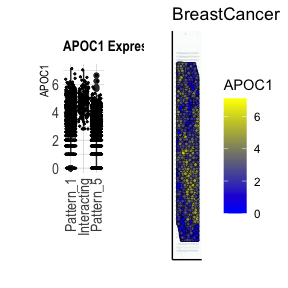

```r
plot_grid(plotlist = list(plist[[1]],plots[[1]]))
```

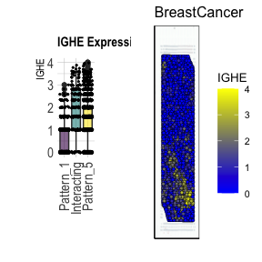

```r
plot_grid(plotlist = list(plist[[2]],plots[[2]]))
```

On the spatial heatmap, Pattern_1 takes up most of the top half of the spatial heatmap, followed by the interacting region along the diagonal and finally Pattern_5 in the bottom left corner. APOC1 is expressed across all patterns but is especially strong in the interacting pattern. IGHE is highly specific to the interacting pattern. The Dunn.pval_1_Int is lower for IGHE compared to APOC1 indicating more significance in the interacting region vs the other two regions. However, the overall SpaceMarkersMetric for APOC1 is higher and so it is ranked higher than IGHE.

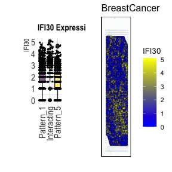

```r
plot_grid(plotlist = list(plist[[3]],plots[[3]]))
```

The spatial heatmap for IFI30 shows fairly high expression in multiple patterns but especially in the interacting regions. This is reflected in the box plots as well with fairly high expression in the interacting pattern vs the other two patterns.

### Pattern_1 Only vs Pattern_5 (including Pattern_5 in interacting region)

#### Table of statistics

```r
head(residual_p1_p2 %>% dplyr::filter(residual_p1_p2$`Pattern_1 x Pattern_5` == "vsPattern_5"),n_genes - 1)
```

```
##      Gene Pattern_1 x Pattern_5 KW.obs.tot KW.obs.groups KW.df KW.statistic
## ING1 ING1           vsPattern_5       2392             3     2     8.247203
## HADH HADH           vsPattern_5       2392             3     2     8.983470
##       KW.pvalue   KW.p.adj Dunn.zP1_Int Dunn.zP2_Int Dunn.zP2_P1
## ING1 0.01618611 0.01764442    -1.951208    -2.743420   -1.388971
## HADH 0.01120119 0.01227372    -1.884545    -2.797468   -1.622130
##      Dunn.pval_1_Int Dunn.pval_2_Int Dunn.pval_2_1 Dunn.pval_1_Int.adj
## ING1      0.05103226     0.006080284     0.1648415           0.1276308
## HADH      0.05949130     0.005150484     0.1047756           0.1473317
##      Dunn.pval_2_Int.adj Dunn.pval_2_1.adj SpaceMarkersMetric
## ING1          0.01728967         0.3814138           5.352984
## HADH          0.01477294         0.2502505           5.271955
```

#### Visualizations

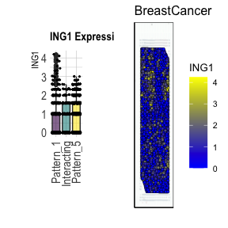

```r
plot_grid(plotlist = list(plist[[4]],plots[[4]]))
```

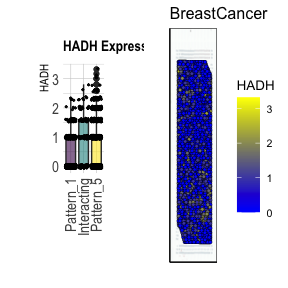

```r
plot_grid(plotlist = list(plist[[5]],plots[[5]]))
```

### Pattern_5 Only vs Pattern_1

#### Table of statistics

```r
head(residual_p1_p2 %>% dplyr::filter(residual_p1_p2$`Pattern_1 x Pattern_5` == "vsPattern_1"),n_genes - 1 )
```

```
##            Gene Pattern_1 x Pattern_5 KW.obs.tot KW.obs.groups KW.df
## RCN1       RCN1           vsPattern_1       2392             3     2
## TMEM147 TMEM147           vsPattern_1       2392             3     2
##         KW.statistic  KW.pvalue   KW.p.adj Dunn.zP1_Int Dunn.zP2_Int
## RCN1        7.458932 0.02400565 0.02600500    -2.644083    -1.947744
## TMEM147     8.512683 0.01417407 0.01548354    -2.733838    -1.857804
##         Dunn.zP2_P1 Dunn.pval_1_Int Dunn.pval_2_Int Dunn.pval_2_1
## RCN1       1.478579     0.008191259      0.05144565    0.13925278
## TMEM147    1.825106     0.006260080      0.06319688    0.06798504
##         Dunn.pval_1_Int.adj Dunn.pval_2_Int.adj Dunn.pval_2_1.adj
## RCN1             0.02288941           0.1285571         0.3261072
## TMEM147          0.01776627           0.1559852         0.1670383
##         SpaceMarkersMetric
## RCN1              5.149996
## TMEM147           5.078935
```

#### Visualizations

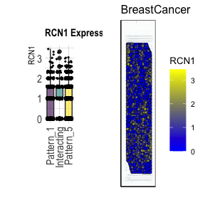

```r
plot_grid(plotlist = list(plist[[7]],plots[[7]]))
```

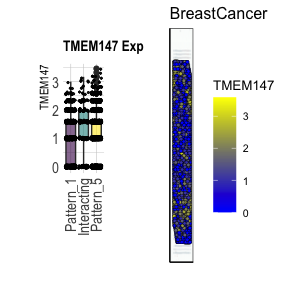

```r
plot_grid(plotlist = list(plist[[8]],plots[[8]]))
```

In this comparison the box plots show high expression of TMEM147 in Pattern_5 and the interacting region compared to Pattern_1. However, the prevalent expression profile for RCN1 is harder to distinguish. Like the Pattern_1 Only vs Pattern_5, the p-values here are relatively high indicating low statistical significance.

## Removing Directories

```r
unlink(sp_file)
files <- list.files(".")[grepl(counts_file,list.files("."))]
unlink(files)
unlink(cogaps_url)
```

## load10XExpr() Arguments

| Argument | Description |
| --- | --- |
| visiumDir | A string path to the h5 file with expression information |
| h5filename | A string of the name of the h5 file in the directory |

## load10XCoords() Arguments

[output not shown]

## getSpatialParameters() Arguments

| Argument | Description |
| --- | --- |
| spatialPatterns | A data frame that contains the spatial coordinates for each cell type. The column names must include ‘x’ and ‘y’ as well as a set of numbered columns named ‘Pattern_1…..N’. |

## getInteractingGenes() Arguments

| Argument | Description |
| --- | --- |
| data | A data frame of expression information with rows being the features/genes and columns being the samples/cells. |
| reconstruction | A data frame of features (rows) and samples (columns) constructed from the information of a latent feature method such as CoGAPs or STdeconvolve. NULL if ‘DE’ mode is specified |
| optParams | A data frame that for each pattern has the sigmaOpts - the optimal width of the gaussian distribution and the thresOpt - outlier threshold around the set of spots. |
| spatialPatterns | A data frame that contains the spatial coordinates for each cell type. The column names must include ‘x’ and ‘y’ as well as a set of numbered columns named ‘Pattern_1…..N’. |
| refPattern | A string of the pattern you want to use to compare to the other patterns in the latent feature space |
| mode | A string specifying either ‘residual’ mode or ‘DE’ mode for finding interacting genes |
| minOverlap | a number that specifies the minimum overlap between genes in two patterns to be considered for the statistical tests. The default is 50. |
| hotspotRegions | a vector that specifies the patterns to compare to the ‘refPattern’. The default is NULL which indicates that all patterns would be compared to the ‘refPattern’. |